# A tale of two cities: evolution of the coronavirus pandemic in Buenos Aires and Chicago

Daniel Gervini

August 3, 2020

# Chicago case

The following plots show the evolution of confirmed cases and deaths in Chicago (or, more precisely, in Cook County, which includes Chicago suburbs and has a population of approximately 5 million.) The circles in the plots are the observed data and the red lines are the estimated curves using the SIRD model.

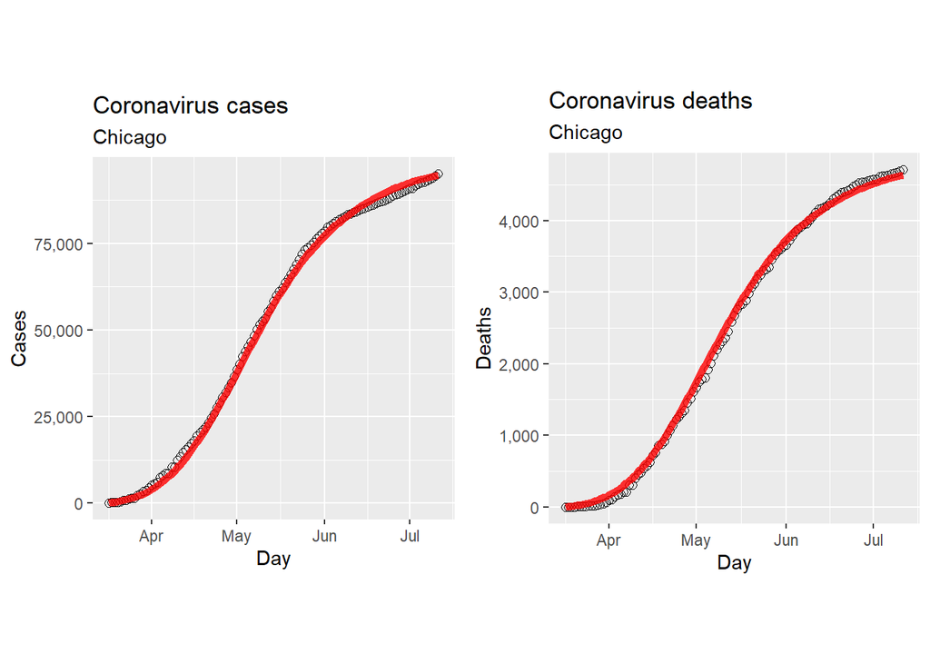

As we can see, the SIRD model approximates the data very well. From this model we can calculate the basic reproduction number [R0](https://en.wikipedia.org/wiki/Basic_reproduction_number) shown next, together with a plot of the daily cases.

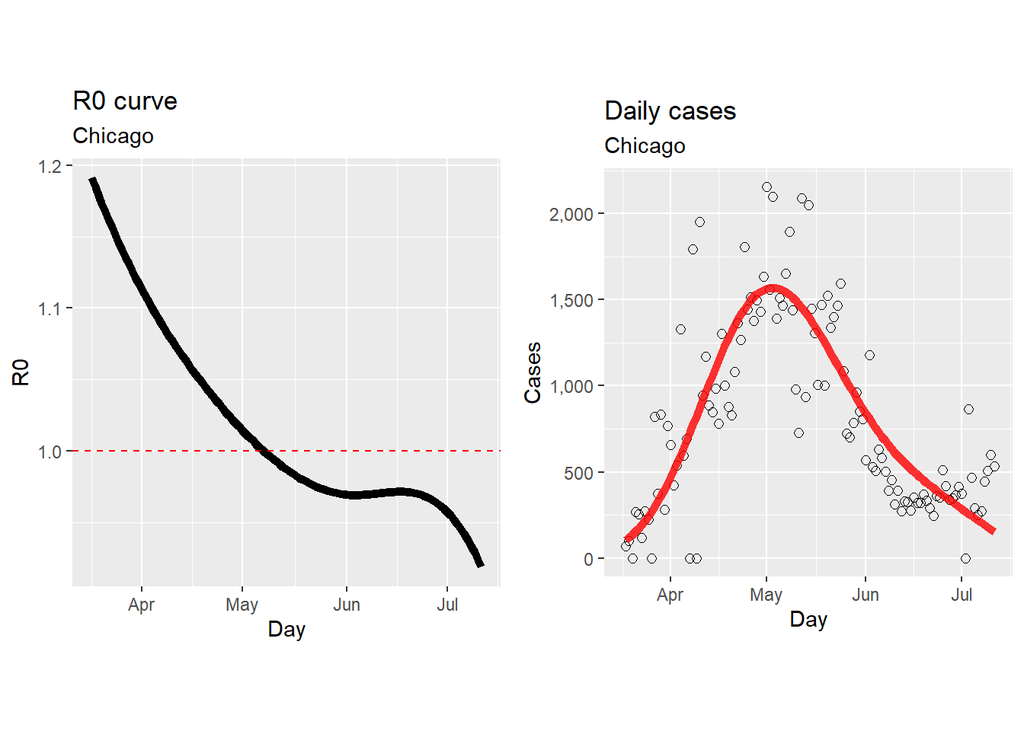

As we can see above, R0 **falls below 1** in early May, so the epidemic peak occurs at that time and the curve of new daily cases begins to go down afterwards. So, the quarantine-like measures worked as expected in Chicago.

# Buenos Aires case

In Buenos Aires case, we consider the city and the suburbs separately.

## Buenos Aires city

The city of Buenos Aires has a population of approximately 3 million. The following plot shows the evolution of confirmed cases and deaths (circles) and the corresponding SIRD model fits (red).

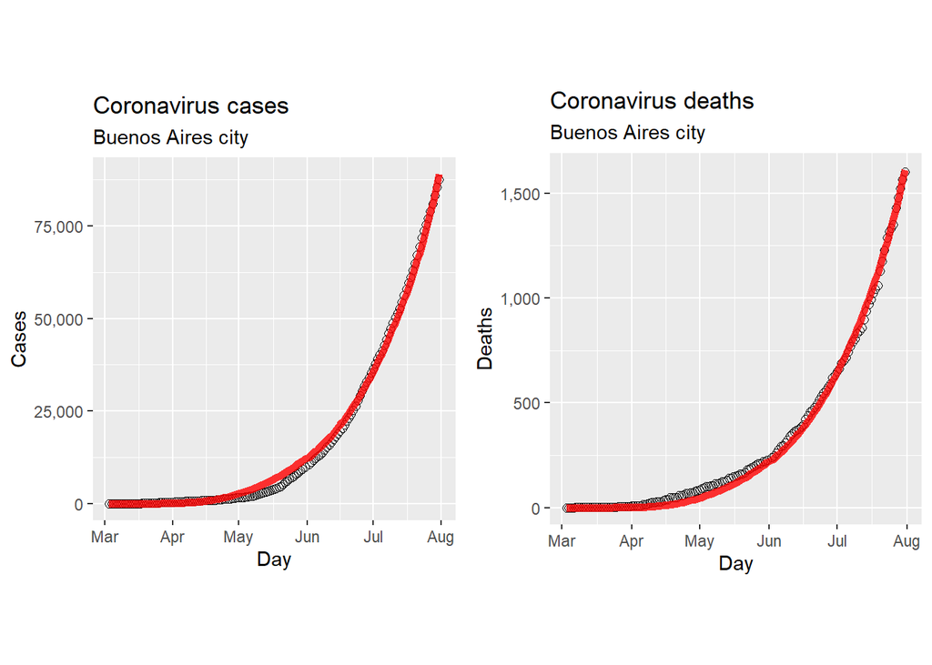

Again, the SIRD model provides a good fit to the data. The R0 curve and daily cases are shown below.

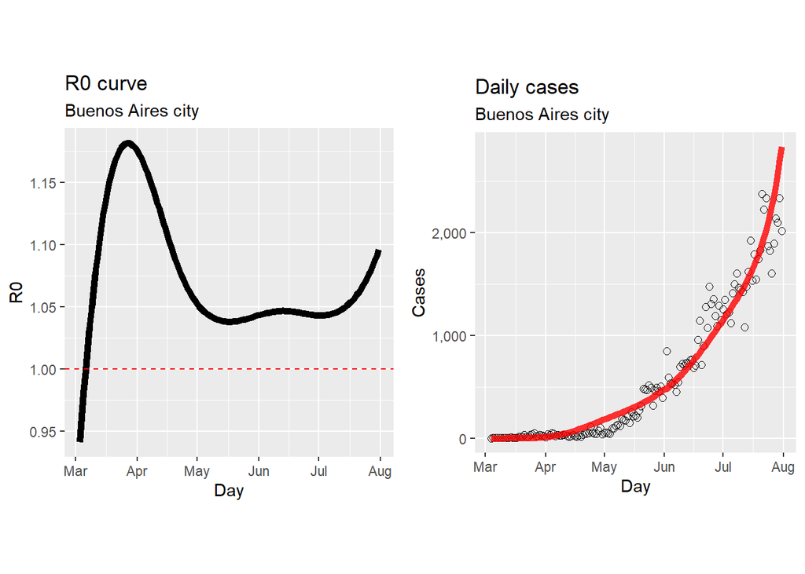

Now we see that, unlike the Chicago case, the R0 curve **never** fell below 1 during the quarantine, so the peak **has not arrived yet** in the city of Buenos Aires; the number of daily cases keeps going up. So, in the city of Buenos Aires the quarantine-like measures only served to push the peak back.

## Buenos Aires suburbs

The 24 districts that make up Buenos Aires suburbs have a population of approximately 11 million. Although I only have data for Buenos Aires province and not specifically for the city suburbs, they are a good approximation to the latter because most of the province’s 16 million inhabitants live in Buenos Aires suburbs; the rest of the cities in the province are widely spread throughout the vast province and relatively isolated from Buenos Aires suburbs.

The following plots show the evolution of confirmed cases and deaths (circles) and SIRD model curves (in red).

[figure not shown]

The R0 curve and the daily cases are shown next.

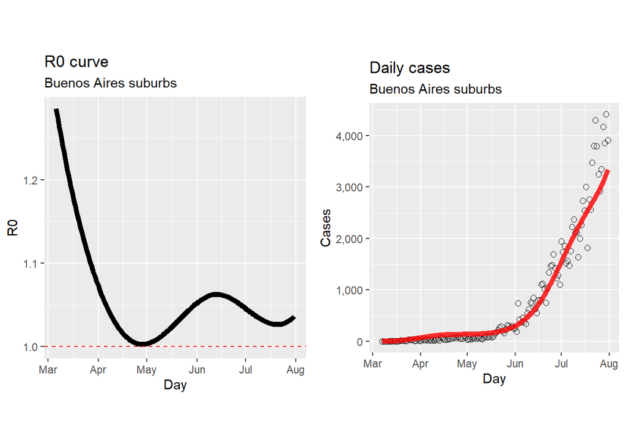

The evolution in Buenos Aires suburbs is similar to that of the city: the R0 curve **did not fall** below 1 during the quarantine, so the number of daily cases keeps going up.

## Forecasts: ¿When (and how) will the peak arrive?

To predict the evolution of the pandemic in Buenos Aires city and suburbs during the next four months, we have to speculate on the values R0 may attain, using the values recently observed as basis.

### Buenos Aires city

As we saw above, in the city of Buenos Aires R0 ranged between 1.04 y 1.10 since May. Using those values as extremes, we calculated predicted trajectories using the SIRD model. Next we show the data observed so far (circles) and the predicted trajectories of total and daily cases and deaths (in blue for the low R0 and red for the high R0).

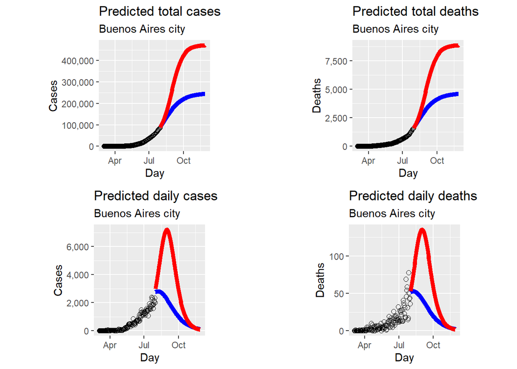

As we see above, if R0 remains at the low value of 1.04, **the peak would be occurring right now**, with around 50 deaths per day and an accumulated total of 4600 deaths by the end of November. ON the other hand, in the more pessimistic case of an R0 at the 1.10 level, the peak would arrive in early September with 135 deaths per day and an accumulated total of 8900 deaths by the end of November.

### Buenos Aires suburbs

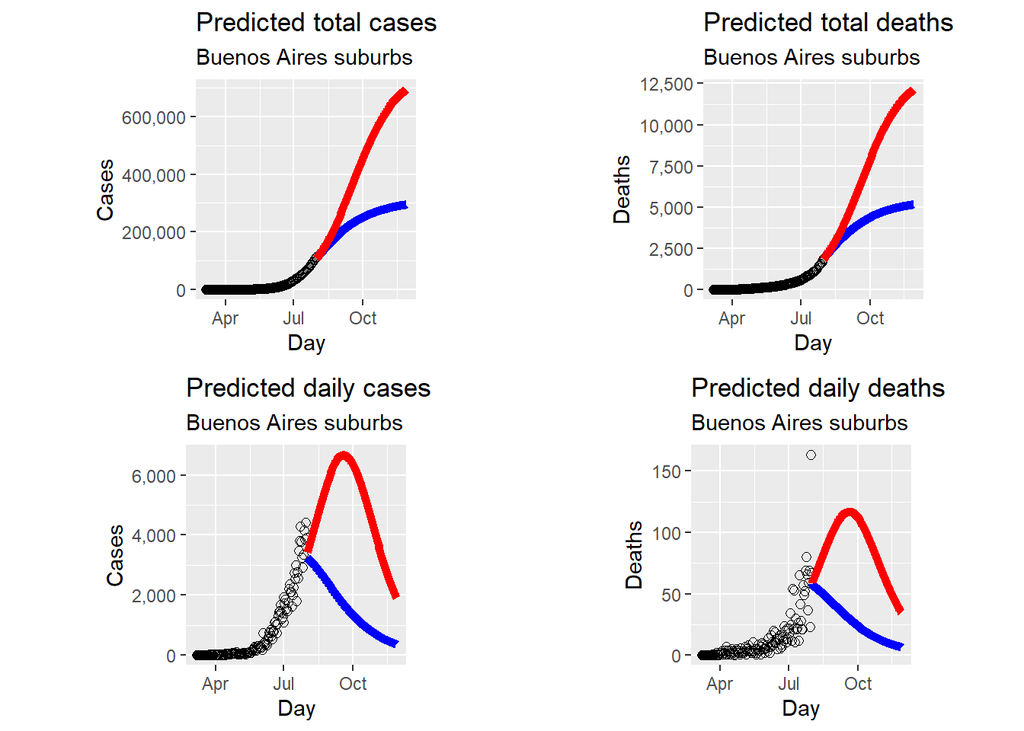

# Conclusions

In Chicago the quarantine-like measures quickly made the R0 number fall below 1 and, consequently, the curve of daily new cases fell quickly and stabilized at a low value since early July. In contrast, in Buenos Aires city and suburbs the quarantine-like measures did not manage to push R0 below 1. Eventually the peak will arrive in Buenos Aires too, but only when the herd-immunity levels corresponding to those R0’s are reached.